# Assignment6 Crime analytics

Yvonne Hua

Janurary 10, 2016

As is shown in Figure 1, total crime counts in San Francisco is slightly higher during later hours in a day, comparing to early morning hours. By eyeballing, there are also more large outliners after 5PM. Which day of the week doesn’t seem to affect total crime counts, while Southern district has signigicantly higher crime counts than other districts.

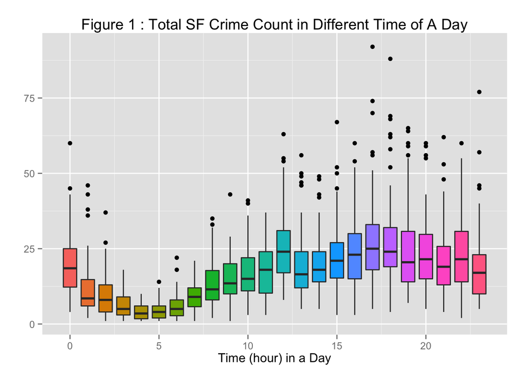

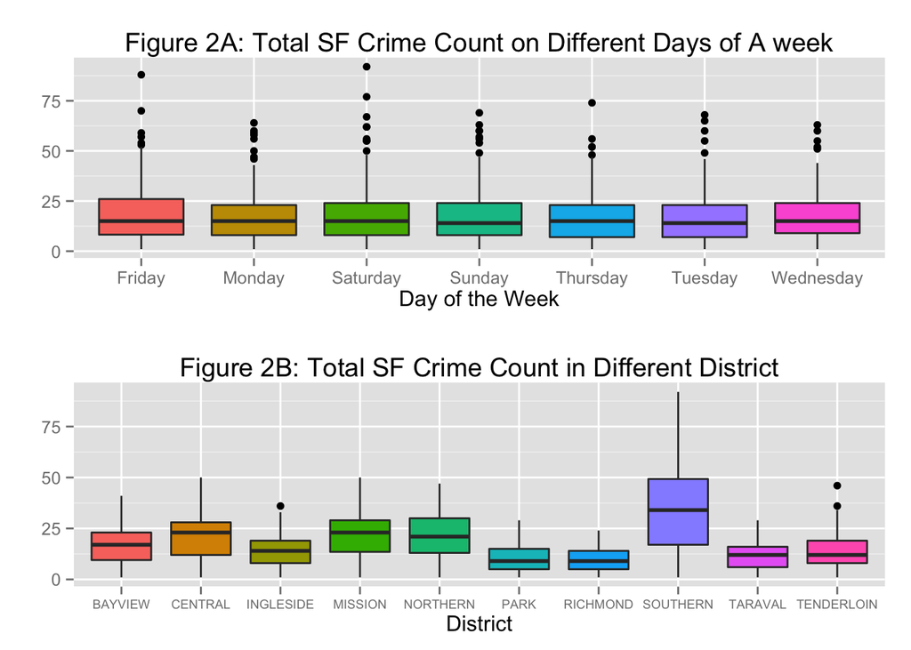

### Comparing San Francisco and Seattle’s crime count distribution during different time of a day.

The limitation of this analysis is that only time of a day and locations are controled. I did not take into account additional information such as weather, or the crime category, which may be important stratification factors. As for Figure 3, since the number of the locations (district in SF and precinct in Seattle) are different, and the total crime numbers are different, it is only a rough comparison of the two cities.

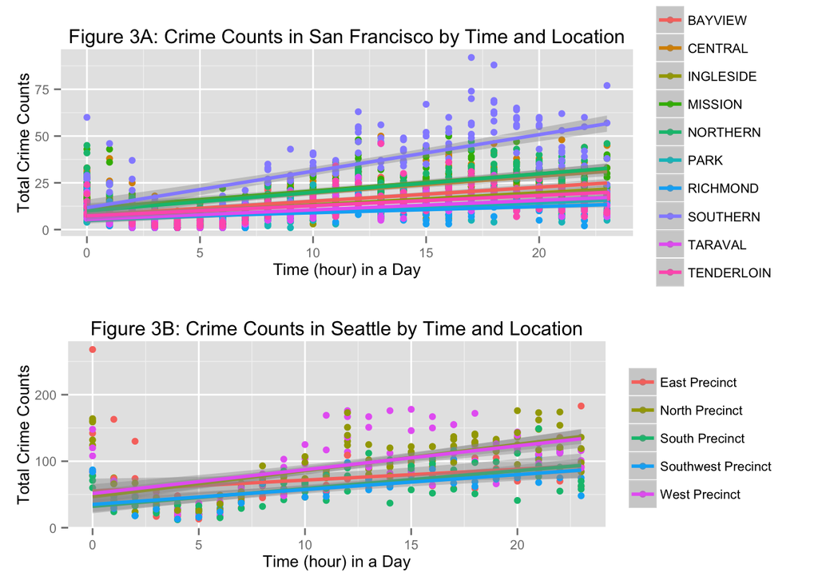